# Project: The movie database (Tmdb movies)

- Introduction
- Data Wrangling
- Exploratory Data Analysis
- Conclusions

## Introduction

### Brief Overview

> This data set contains information about 10,000 movies collected from The Movie Database (TMDb),including user ratings and revenue. I will perform some wrangling and EDA in order to address some research questions.To get more visual informations , I will use matplotlib to get more insights with visual patterns.
> - Certain columns, like 'cast', 'director' and 'genres', contain multiple values separated by pipe (|) characters.
> - There are some odd characters in the 'cast' column.
> - The final two columns ending with '_adj' show the budget and revenue of the associated movie in terms of 2010 dollars, accounting for inflation over time.

### Questions for Analysis

> 1. Which genres are most popular from year to year?
> 2. What kinds of properties are associated with movies that have high revenues?
> 3. Do the movies that get high ratings by the audience depend on their length?
> 4. Movies runtime is the same over the years?
> 5. Top 20 directors in terms of number of movies released?
> 6. Type of movies which has the longest duration?

```python
# set up import statements for all of the packages that I'll use.
import pandas as pd
import numpy as np
import seaborn as sns
from matplotlib import pyplot as plt
%matplotlib inline
```

## Data Wrangling

> In this section I will load in the data, check for cleanliness, trim and prepare the dataset for analysis.

### General Properties

```python
#loading the data
df = pd.read_csv('tmdb-movies.csv')
#investigating the columns which are present
df.head(3)
```

|  | id | imdb_id | popularity | budget | revenue | original_title | cast | homepage | director | tagline | ... | overview | runtime | genres | production_companies | release_date | vote_count | vote_average | release_year | budget_adj | revenue_adj |
| --- | --- | --- | --- | --- | --- | --- | --- | --- | --- | --- | --- | --- | --- | --- | --- | --- | --- | --- | --- | --- | --- |
| 0 | 135397 | tt0369610 | 32.985763 | 150000000 | 1513528810 | Jurassic World | Chris Pratt\|Bryce Dallas Howard\|Irrfan Khan\|Vi... | http://www.jurassicworld.com/ | Colin Trevorrow | The park is open. | ... | Twenty-two years after the events of Jurassic ... | 124 | Action\|Adventure\|Science Fiction\|Thriller | Universal Studios\|Amblin Entertainment\|Legenda... | 6/9/15 | 5562 | 6.5 | 2015 | 1.379999e+08 | 1.392446e+09 |
| 1 | 76341 | tt1392190 | 28.419936 | 150000000 | 378436354 | Mad Max: Fury Road | Tom Hardy\|Charlize Theron\|Hugh Keays-Byrne\|Nic... | http://www.madmaxmovie.com/ | George Miller | What a Lovely Day. | ... | An apocalyptic story set in the furthest reach... | 120 | Action\|Adventure\|Science Fiction\|Thriller | Village Roadshow Pictures\|Kennedy Miller Produ... | 5/13/15 | 6185 | 7.1 | 2015 | 1.379999e+08 | 3.481613e+08 |
| 2 | 262500 | tt2908446 | 13.112507 | 110000000 | 295238201 | Insurgent | Shailene Woodley\|Theo James\|Kate Winslet\|Ansel... | http://www.thedivergentseries.movie/#insurgent | Robert Schwentke | One Choice Can Destroy You | ... | Beatrice Prior must confront her inner demons ... | 119 | Adventure\|Science Fiction\|Thriller | Summit Entertainment\|Mandeville Films\|Red Wago... | 3/18/15 | 2480 | 6.3 | 2015 | 1.012000e+08 | 2.716190e+08 |

3 rows × 21 columns

```python
# checking the datatypes for each column
df.dtypes
```

```
id                        int64
imdb_id                  object
popularity              float64
budget                    int64
revenue                   int64
original_title           object
cast                     object
homepage                 object
director                 object
tagline                  object
keywords                 object
overview                 object
runtime                   int64
genres                   object
production_companies     object
release_date             object
vote_count                int64
vote_average            float64
release_year              int64
budget_adj              float64
revenue_adj             float64
dtype: object
```

```python
# getting the number of rows and columns in the dataset
df.shape
```

```
(10866, 21)
```

# Info for the dataset

The dataset contains more than 10,000 movies with **21 variables**.  
Those Variables are :

- id
- imdb_id
- popularity
- budget
- revenue
- original_title
- cast
- homepage
- director
- tagline
- keywords
- overview
- runtime
- genres
- production_companies
- release_date
- vote_count
- vote_average
- release_year
- budget_adj
- revenue_adj
> - **imdb_id** : will not use as its not necessary for my analysis.
> - **budget_adj** and **revenue_adj** : will not be necessary as they consider only the inflammation overtime in 2010 dollars and I already have **budget** and **revenue** so I will neglect both of them.
> - **homepage**, **overview**, **tagline** and **keywords** columns: they are not playing an important role in our analysis and they have unique values for each row so we can't consider them.

```python
#checking for null values to drop them
df.isnull().sum()
```

```
id                         0
imdb_id                   10
popularity                 0
budget                     0
revenue                    0
original_title             0
cast                      76
homepage                7930
director                  44
tagline                 2824
keywords                1493
overview                   4
runtime                    0
genres                    23
production_companies    1030
release_date               0
vote_count                 0
vote_average               0
release_year               0
budget_adj                 0
revenue_adj                0
dtype: int64
```

> There is alot of entries that have null values for different attributes which are :imdb_id, cast, homepage,director, tagline, keywords, overviw, genres and production companies.I will drop imdb_id, homepage, overview, tagline and keywords columns as they have alot of nulls and they are not playing an important role in our analysis.

```python
# Getting the statistics for each column
df.describe()
```

|  | id | popularity | budget | revenue | runtime | vote_count | vote_average | release_year | budget_adj | revenue_adj |
| --- | --- | --- | --- | --- | --- | --- | --- | --- | --- | --- |
| count | 10866.000000 | 10866.000000 | 1.086600e+04 | 1.086600e+04 | 10866.000000 | 10866.000000 | 10866.000000 | 10866.000000 | 1.086600e+04 | 1.086600e+04 |
| mean | 66064.177434 | 0.646441 | 1.462570e+07 | 3.982332e+07 | 102.070863 | 217.389748 | 5.974922 | 2001.322658 | 1.755104e+07 | 5.136436e+07 |
| std | 92130.136561 | 1.000185 | 3.091321e+07 | 1.170035e+08 | 31.381405 | 575.619058 | 0.935142 | 12.812941 | 3.430616e+07 | 1.446325e+08 |
| min | 5.000000 | 0.000065 | 0.000000e+00 | 0.000000e+00 | 0.000000 | 10.000000 | 1.500000 | 1960.000000 | 0.000000e+00 | 0.000000e+00 |
| 25% | 10596.250000 | 0.207583 | 0.000000e+00 | 0.000000e+00 | 90.000000 | 17.000000 | 5.400000 | 1995.000000 | 0.000000e+00 | 0.000000e+00 |
| 50% | 20669.000000 | 0.383856 | 0.000000e+00 | 0.000000e+00 | 99.000000 | 38.000000 | 6.000000 | 2006.000000 | 0.000000e+00 | 0.000000e+00 |
| 75% | 75610.000000 | 0.713817 | 1.500000e+07 | 2.400000e+07 | 111.000000 | 145.750000 | 6.600000 | 2011.000000 | 2.085325e+07 | 3.369710e+07 |
| max | 417859.000000 | 32.985763 | 4.250000e+08 | 2.781506e+09 | 900.000000 | 9767.000000 | 9.200000 | 2015.000000 | 4.250000e+08 | 2.827124e+09 |

> Observed from the dataset that some rows for the budget, revenue, and runtime contains zero values. That means that maybe those movies aren't released but the min release date is 1960 that means that their data is missing.

```python
# checking if the number of budget rows with zero is large or not
df.groupby('budget').count()['id'].head()
```

```
budget
0    5696
1       4
2       1
3       3
5       1
Name: id, dtype: int64
```

```python
# checking if the number of revenue rows with zero is large or not

df.groupby('revenue').count()['id'].head()
```

```
revenue
0    6016
2       2
3       3
5       2
6       2
Name: id, dtype: int64
```

```python
# checking if the number of runtime rows with zero is large or not

df.groupby('runtime').count()['id'].head()
```

```
runtime
0    31
2     5
3    11
4    17
5    17
Name: id, dtype: int64
```

> Checking the number of zero values for each of the **budget, revenue and runtime**, since the number of zero values are large for the budget and revenue, I'll replace all the zero values with null values and drop those rows to not affect the analysis process.The number of zero runtime rows are small so I can drop it without affecting the analysis.

### Data Cleaning

> 1. Dropping some columns which not useful for the analysis.
> 2. Fill the null values with zero.
> 3. Replace zero with null values for important attributes.
> 4. Drop rows with zero values that will affect the analysis.
> 5. Remove some duplicates from the dataset.
> 6. Change the release date from string to datetime format.
> 7. Function for splitting cells containing a seperator.

### 1. Dropping some columns which not useful for the analysis.

> Removing those columns will not affect our analysis as they are unique for each row in the entire datasste.

```python
# Dropping some columns which not useful for the analysis.

df.drop(columns=['homepage','tagline','keywords','imdb_id','overview','revenue_adj','budget_adj'], axis=1, inplace=True)
```

```python
df.head(1)
```

|  | id | popularity | budget | revenue | original_title | cast | director | runtime | genres | production_companies | release_date | vote_count | vote_average | release_year |
| --- | --- | --- | --- | --- | --- | --- | --- | --- | --- | --- | --- | --- | --- | --- |
| 0 | 135397 | 32.985763 | 150000000 | 1513528810 | Jurassic World | Chris Pratt\|Bryce Dallas Howard\|Irrfan Khan\|Vi... | Colin Trevorrow | 124 | Action\|Adventure\|Science Fiction\|Thriller | Universal Studios\|Amblin Entertainment\|Legenda... | 6/9/15 | 5562 | 6.5 | 2015 |

### 2. Fill the null values with zero.

> filling those null values with zero cause they will not affect our analysis, as cast and director name for example having small number of rows with null values so it's not a big deal.

```python
# checking the number of rows with null values after dropping some columns
df.isnull().sum()
```

```
id                         0
popularity                 0
budget                     0
revenue                    0
original_title             0
cast                      76
director                  44
runtime                    0
genres                    23
production_companies    1030
release_date               0
vote_count                 0
vote_average               0
release_year               0
dtype: int64
```

```python
# filling nan with zero
df.fillna(0,inplace=True)
df.isnull().sum()
```

```
id                      0
popularity              0
budget                  0
revenue                 0
original_title          0
cast                    0
director                0
runtime                 0
genres                  0
production_companies    0
release_date            0
vote_count              0
vote_average            0
release_year            0
dtype: int64
```

### 3. Replace zero with null values for important attributes.

> zero values for budget and revenue will affect the analysis for our dataset, so seeking the best way to remove them is important, although removing like 60% of the data of course will affect the analysis and this is one of the limitations of the project.

```python
# Replacing the zeroes in budget and revenue columns to drop those rows easily
df['budget']=df['budget'].replace(0,np.nan)
df['revenue']=df['revenue'].replace(0,np.nan)
# dropping those null values
df.dropna(inplace=True)
# checking that the data is now distributed in bettery way
df.describe()
```

|  | id | popularity | budget | revenue | runtime | vote_count | vote_average | release_year |
| --- | --- | --- | --- | --- | --- | --- | --- | --- |
| count | 3855.000000 | 3855.000000 | 3.855000e+03 | 3.855000e+03 | 3855.000000 | 3855.000000 | 3855.00000 | 3855.000000 |
| mean | 39888.783398 | 1.191400 | 3.720183e+07 | 1.076589e+08 | 109.215824 | 527.611933 | 6.16786 | 2001.263294 |
| std | 67213.815955 | 1.475002 | 4.220291e+07 | 1.765248e+08 | 19.922166 | 879.868374 | 0.79504 | 11.281989 |
| min | 5.000000 | 0.001117 | 1.000000e+00 | 2.000000e+00 | 15.000000 | 10.000000 | 2.20000 | 1960.000000 |
| 25% | 6074.000000 | 0.462448 | 1.000000e+07 | 1.357645e+07 | 95.000000 | 71.000000 | 5.70000 | 1995.000000 |
| 50% | 11322.000000 | 0.797298 | 2.400000e+07 | 4.479322e+07 | 106.000000 | 204.000000 | 6.20000 | 2004.000000 |
| 75% | 38577.000000 | 1.368245 | 5.000000e+07 | 1.241530e+08 | 119.000000 | 580.000000 | 6.70000 | 2010.000000 |
| max | 417859.000000 | 32.985763 | 4.250000e+08 | 2.781506e+09 | 338.000000 | 9767.000000 | 8.40000 | 2015.000000 |

### 4. Drop rows with zero values that will affect the analysis.

> dropping the zero values for runtime will not affect the analysis as they are very small part of the dataset.

```python
df.drop(df.index[df['runtime'] == 0], inplace = True)
df.groupby('runtime').count()['id'].head(2)
```

```
runtime
15    1
26    1
Name: id, dtype: int64
```

```python
# checking that the data is now distributed in bettery way
df.describe()
```

|  | id | popularity | budget | revenue | runtime | vote_count | vote_average | release_year |
| --- | --- | --- | --- | --- | --- | --- | --- | --- |
| count | 3855.000000 | 3855.000000 | 3.855000e+03 | 3.855000e+03 | 3855.000000 | 3855.000000 | 3855.00000 | 3855.000000 |
| mean | 39888.783398 | 1.191400 | 3.720183e+07 | 1.076589e+08 | 109.215824 | 527.611933 | 6.16786 | 2001.263294 |
| std | 67213.815955 | 1.475002 | 4.220291e+07 | 1.765248e+08 | 19.922166 | 879.868374 | 0.79504 | 11.281989 |
| min | 5.000000 | 0.001117 | 1.000000e+00 | 2.000000e+00 | 15.000000 | 10.000000 | 2.20000 | 1960.000000 |
| 25% | 6074.000000 | 0.462448 | 1.000000e+07 | 1.357645e+07 | 95.000000 | 71.000000 | 5.70000 | 1995.000000 |
| 50% | 11322.000000 | 0.797298 | 2.400000e+07 | 4.479322e+07 | 106.000000 | 204.000000 | 6.20000 | 2004.000000 |
| 75% | 38577.000000 | 1.368245 | 5.000000e+07 | 1.241530e+08 | 119.000000 | 580.000000 | 6.70000 | 2010.000000 |
| max | 417859.000000 | 32.985763 | 4.250000e+08 | 2.781506e+09 | 338.000000 | 9767.000000 | 8.40000 | 2015.000000 |

### 5. Remove some duplicates from the dataset.

```python
# checking number of duplicates

df.duplicated().sum()
```

```
1
```

```python
#Remove duplicates

df.drop_duplicates(inplace=True)
df.duplicated().sum()
```

```
0
```

```python
# checking the number of rows and columns in the dataset

df.shape
```

```
(3854, 14)
```

> The number of rows in the dataset now is reduced by nearly 60% of the total on ground number. That will affect our analysis as it may not be much accurate.

### 6. Change the release date from string to datetime format.

```python
#using to datetime function to change the format for this column from string to datetime to be easily used.
df['release_date']= pd.to_datetime(df['release_date'])
df.head(1)
```

|  | id | popularity | budget | revenue | original_title | cast | director | runtime | genres | production_companies | release_date | vote_count | vote_average | release_year |
| --- | --- | --- | --- | --- | --- | --- | --- | --- | --- | --- | --- | --- | --- | --- |
| 0 | 135397 | 32.985763 | 150000000.0 | 1.513529e+09 | Jurassic World | Chris Pratt\|Bryce Dallas Howard\|Irrfan Khan\|Vi... | Colin Trevorrow | 124 | Action\|Adventure\|Science Fiction\|Thriller | Universal Studios\|Amblin Entertainment\|Legenda... | 2015-06-09 | 5562 | 6.5 | 2015 |

```python
df.dtypes
```

```
id                               int64
popularity                     float64
budget                         float64
revenue                        float64
original_title                  object
cast                            object
director                        object
runtime                          int64
genres                          object
production_companies            object
release_date            datetime64[ns]
vote_count                       int64
vote_average                   float64
release_year                     int64
dtype: object
```

### 7. Function for splitting cells containing a seperator.

```python
#used for splitting any cells containing any separator by giving it the dataframe,column name that need to split,
#separater character and returning the new dataframe

def split_cell(df,column_name,sep):
    df=df.set_index(df.columns.difference([column_name],sort=False).tolist()).apply(lambda x: x.str.split(sep).explode()).reset_index()
    return df
```

> Splitting the genres cells into multiple rows to have 1 genre in each for each movie.

```python
#Splitting the genres cells

df=split_cell(df,'genres','|')
df.head()
```

|  | id | popularity | budget | revenue | original_title | cast | director | runtime | production_companies | release_date | vote_count | vote_average | release_year | genres |
| --- | --- | --- | --- | --- | --- | --- | --- | --- | --- | --- | --- | --- | --- | --- |
| 0 | 135397 | 32.985763 | 150000000.0 | 1.513529e+09 | Jurassic World | Chris Pratt\|Bryce Dallas Howard\|Irrfan Khan\|Vi... | Colin Trevorrow | 124 | Universal Studios\|Amblin Entertainment\|Legenda... | 2015-06-09 | 5562 | 6.5 | 2015 | Action |
| 1 | 135397 | 32.985763 | 150000000.0 | 1.513529e+09 | Jurassic World | Chris Pratt\|Bryce Dallas Howard\|Irrfan Khan\|Vi... | Colin Trevorrow | 124 | Universal Studios\|Amblin Entertainment\|Legenda... | 2015-06-09 | 5562 | 6.5 | 2015 | Adventure |
| 2 | 135397 | 32.985763 | 150000000.0 | 1.513529e+09 | Jurassic World | Chris Pratt\|Bryce Dallas Howard\|Irrfan Khan\|Vi... | Colin Trevorrow | 124 | Universal Studios\|Amblin Entertainment\|Legenda... | 2015-06-09 | 5562 | 6.5 | 2015 | Science Fiction |
| 3 | 135397 | 32.985763 | 150000000.0 | 1.513529e+09 | Jurassic World | Chris Pratt\|Bryce Dallas Howard\|Irrfan Khan\|Vi... | Colin Trevorrow | 124 | Universal Studios\|Amblin Entertainment\|Legenda... | 2015-06-09 | 5562 | 6.5 | 2015 | Thriller |
| 4 | 76341 | 28.419936 | 150000000.0 | 3.784364e+08 | Mad Max: Fury Road | Tom Hardy\|Charlize Theron\|Hugh Keays-Byrne\|Nic... | George Miller | 120 | Village Roadshow Pictures\|Kennedy Miller Produ... | 2015-05-13 | 6185 | 7.1 | 2015 | Action |

```python
#Splitting the director cells

df=split_cell(df,'director','|')
df.tail()
```

|  | id | popularity | budget | revenue | original_title | cast | runtime | production_companies | release_date | vote_count | vote_average | release_year | genres | director |
| --- | --- | --- | --- | --- | --- | --- | --- | --- | --- | --- | --- | --- | --- | --- |
| 11191 | 5923 | 0.299911 | 12000000.0 | 20000000.0 | The Sand Pebbles | Steve McQueen\|Richard Attenborough\|Richard Cre... | 182 | Twentieth Century Fox Film Corporation\|Solar P... | 2066-12-20 | 28 | 7.0 | 1966 | Drama | Robert Wise |
| 11192 | 5923 | 0.299911 | 12000000.0 | 20000000.0 | The Sand Pebbles | Steve McQueen\|Richard Attenborough\|Richard Cre... | 182 | Twentieth Century Fox Film Corporation\|Solar P... | 2066-12-20 | 28 | 7.0 | 1966 | War | Robert Wise |
| 11193 | 5923 | 0.299911 | 12000000.0 | 20000000.0 | The Sand Pebbles | Steve McQueen\|Richard Attenborough\|Richard Cre... | 182 | Twentieth Century Fox Film Corporation\|Solar P... | 2066-12-20 | 28 | 7.0 | 1966 | Romance | Robert Wise |
| 11194 | 2161 | 0.207257 | 5115000.0 | 12000000.0 | Fantastic Voyage | Stephen Boyd\|Raquel Welch\|Edmond O'Brien\|Donal... | 100 | Twentieth Century Fox Film Corporation | 2066-08-24 | 42 | 6.7 | 1966 | Adventure | Richard Fleischer |
| 11195 | 2161 | 0.207257 | 5115000.0 | 12000000.0 | Fantastic Voyage | Stephen Boyd\|Raquel Welch\|Edmond O'Brien\|Donal... | 100 | Twentieth Century Fox Film Corporation | 2066-08-24 | 42 | 6.7 | 1966 | Science Fiction | Richard Fleischer |

## Exploratory Data Analysis

### Exploring each attribute in our data set

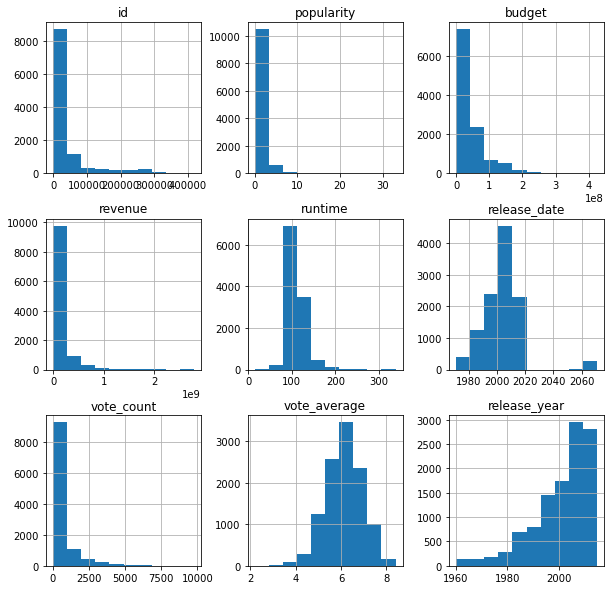

```python
df.hist(figsize=(10,10));
```

### Genres distribution

```python
df_pie = df.groupby('genres')['id'].count().sort_values(ascending=False).reset_index(name="count")
df_pie
```

|  | genres | count |
| --- | --- | --- |
| 0 | Drama | 1834 |
| 1 | Comedy | 1504 |
| 2 | Thriller | 1253 |
| 3 | Action | 1160 |
| 4 | Adventure | 835 |
| 5 | Romance | 704 |
| 6 | Crime | 671 |
| 7 | Science Fiction | 558 |
| 8 | Family | 538 |
| 9 | Horror | 492 |
| 10 | Fantasy | 450 |
| 11 | Mystery | 348 |
| 12 | Animation | 318 |
| 13 | Music | 153 |
| 14 | History | 134 |
| 15 | War | 123 |
| 16 | Western | 58 |
| 17 | Documentary | 48 |
| 18 | Foreign | 14 |
| 19 | TV Movie | 1 |

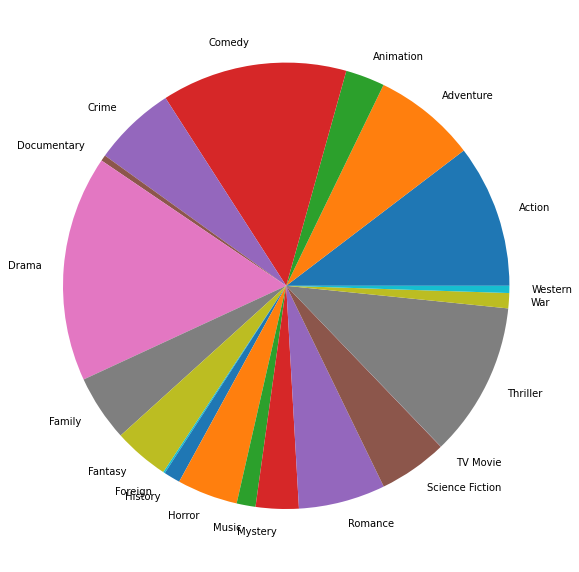

```python
df_pie = df.groupby('genres')['id'].count().reset_index(name="count")
fig = plt.figure(figsize =(10, 15))
plt.pie(df_pie['count'],labels=df_pie['genres']);
```

> Drama and comedy genres are always the most type of movies released.

### 1. Which genres are most popular from year to year?

> Getting the different genres for just the movies which have popularity more than the mean value over the years.

```python
# getting the mean value for the popularity
mean_popularity=df['popularity'].mean()
#copying the original dataframe to a new one for this specific question
df_genre=df.copy()

mean_popularity
```

```
1.2878064744551625
```

```python
# First getting all the rows which has popularity greater than the mean which is equal to approx 1.
# then grouping by genres and release year
# counting the number of movies for each genre for each year and saving the counts in a new column
#sorting the counts in descending order to get the max count for each genre for each year at the top
# then removing duplicates to get just the max genre only
df_genre=df_genre.query('popularity >={}'.format(mean_popularity)).groupby(['release_year','genres'])['popularity'].count().reset_index(name="count").sort_values(by=['release_year','count'],ascending=False,axis=0).drop_duplicates(subset='release_year')
df_genre
```

|  | release_year | genres | count |
| --- | --- | --- | --- |
| 572 | 2015 | Drama | 45 |
| 551 | 2014 | Action | 45 |
| 535 | 2013 | Action | 31 |
| 518 | 2012 | Action | 27 |
| 506 | 2011 | Comedy | 23 |
| 487 | 2010 | Action | 27 |
| 475 | 2009 | Comedy | 20 |
| 462 | 2008 | Drama | 21 |
| 455 | 2007 | Thriller | 21 |
| 430 | 2006 | Comedy | 15 |
| 412 | 2005 | Action | 17 |
| 400 | 2004 | Comedy | 22 |
| 381 | 2003 | Action | 20 |
| 366 | 2002 | Action | 12 |
| 353 | 2001 | Comedy | 14 |
| 338 | 2000 | Comedy | 9 |
| 327 | 1999 | Drama | 12 |
| 307 | 1998 | Adventure | 9 |
| 305 | 1997 | Thriller | 11 |
| 285 | 1996 | Drama | 7 |
| 270 | 1995 | Drama | 10 |
| 257 | 1994 | Crime | 6 |
| 244 | 1993 | Drama | 5 |
| 229 | 1992 | Adventure | 4 |
| 223 | 1991 | Fantasy | 4 |
| 203 | 1990 | Action | 5 |
| 191 | 1989 | Action | 9 |
| 184 | 1988 | Comedy | 4 |
| 171 | 1987 | Action | 5 |
| 160 | 1986 | Action | 4 |
| 151 | 1985 | Adventure | 7 |
| 138 | 1984 | Action | 4 |
| 132 | 1983 | Action | 4 |
| 129 | 1982 | Science Fiction | 4 |
| 117 | 1981 | Action | 2 |
| 109 | 1980 | Comedy | 4 |
| 104 | 1979 | Science Fiction | 4 |
| 95 | 1978 | Horror | 1 |
| 89 | 1977 | Adventure | 5 |
| 87 | 1976 | Drama | 2 |
| 78 | 1975 | Adventure | 3 |
| 74 | 1974 | Crime | 2 |
| 71 | 1973 | Thriller | 2 |
| 63 | 1972 | Crime | 1 |
| 61 | 1971 | Science Fiction | 2 |
| 52 | 1970 | Adventure | 1 |
| 45 | 1969 | Action | 1 |
| 42 | 1968 | Adventure | 1 |
| 35 | 1967 | Adventure | 7 |
| 27 | 1965 | Action | 1 |
| 20 | 1964 | Comedy | 2 |
| 15 | 1963 | Action | 1 |
| 12 | 1962 | Action | 1 |
| 8 | 1961 | Comedy | 4 |
| 0 | 1960 | Action | 1 |

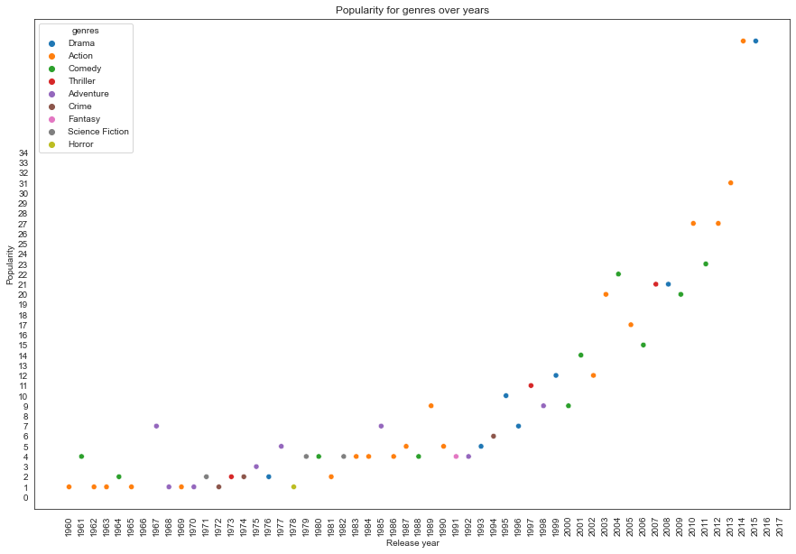

```python
#Visualization
plt.figure(figsize=(15,10))
sns.set_style("white")
plt.title('Popularity for genres over years')
plt.xlabel('Release year')
plt.ylabel('Popularity')
plt.xticks(np.arange(df_genre.release_year.min(), df_genre.release_year.max()+5))
plt.xticks(rotation=90)
plt.yticks(np.arange(0, 35))
sns.scatterplot(x="release_year", y="count", hue="genres", data=df_genre);
```

### 2. What kinds of properties are associated with movies that have high revenues?

> By checking the correlation between the associated columns, it is observed that a positive correlation between the revenue and the budget, profit and popularity of movies.

```python
df_revenue=df.loc[:, ('budget','revenue','vote_average','popularity','runtime')]
# calculating the net profit to get the correlaltion between it and the revenue
df_revenue['profit']=df_revenue['revenue']-df_revenue['budget']
#calculating the correlaltion between all columns which is imp to us
df_revenue.corr()
```

|  | budget | revenue | vote_average | popularity | runtime | profit |
| --- | --- | --- | --- | --- | --- | --- |
| budget | 1.000000 | 0.680719 | 0.059880 | 0.447998 | 0.206823 | 0.521149 |
| revenue | 0.680719 | 1.000000 | 0.258776 | 0.618774 | 0.197921 | 0.979958 |
| vote_average | 0.059880 | 0.258776 | 1.000000 | 0.331702 | 0.302461 | 0.285208 |
| popularity | 0.447998 | 0.618774 | 0.331702 | 1.000000 | 0.185209 | 0.599088 |
| runtime | 0.206823 | 0.197921 | 0.302461 | 0.185209 | 1.000000 | 0.174349 |
| profit | 0.521149 | 0.979958 | 0.285208 | 0.599088 | 0.174349 | 1.000000 |

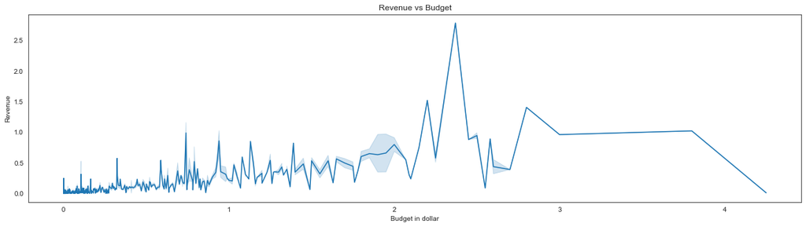

```python
plt.figure(figsize=(20,5))
# dividing just for better visulization
sns.lineplot( x=df_revenue.budget/10**8,y=df_revenue.revenue/10**9)
plt.title('Revenue vs Budget')
plt.ylabel('Revenue')
plt.xlabel('Budget in dollar');
```

> There is a high positive correlation between the budget and the revenue which is equal to 68%. typically a movie that has high budget will get high revenue as all the money paid is for improving quality or any needed visual effects.

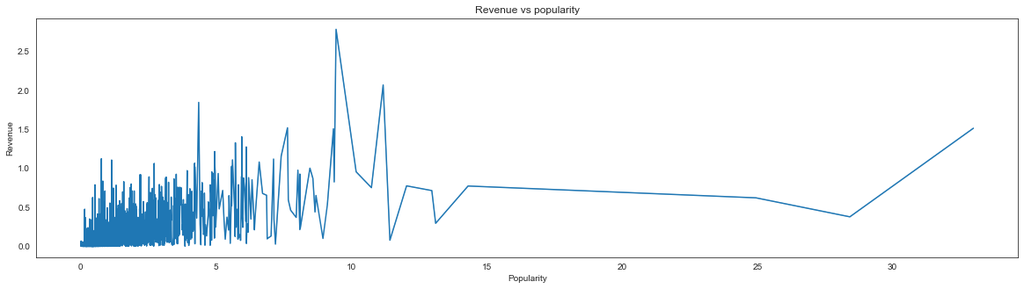

```python
plt.figure(figsize=(20,5))
sns.lineplot( x=df_revenue.popularity,y=df_revenue.revenue/10**9)
plt.title('Revenue vs popularity')
plt.ylabel('Revenue')
plt.xlabel('Popularity');
```

> There is correlation between the popularity and revenue with 61%. for medium popularity movies they have almost the same revenue.

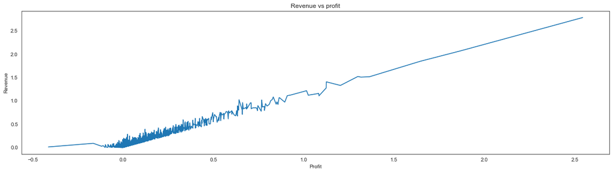

```python
plt.figure(figsize=(20,5))
sns.lineplot( x=df_revenue.profit/10**9,y=df_revenue.revenue/10**9)
plt.title('Revenue vs profit')
plt.ylabel('Revenue')
plt.xlabel('Profit');
```

> There is a high positive correlation between the profit and the revenue by 97%. that means that those movies after spending some budget on them they gain alot of profit after release and that part of movie success.

```python
#The profit for all genres with revenue
mean_revenue=df['revenue'].mean()

#calculating net profit
df['profit']=df['revenue']-df['budget']

# for better visulization
df['profit']=df['profit']/10**9
df['revenue']=df['revenue']/10**9
```

```python
# getting the sum of profit and revenue for each of genre in descending order
df_rev=df.groupby(['genres']).agg({'revenue':'sum','profit':'sum'}).sort_values(by='revenue', ascending=False)
df_rev
```

| genres | revenue | profit |
| --- | --- | --- |
| Adventure | 184.989628 | 126.364875 |
| Action | 179.097812 | 114.383507 |
| Comedy | 156.814928 | 105.236358 |
| Drama | 135.255561 | 84.486826 |
| Thriller | 120.974319 | 74.470654 |
| Family | 119.294036 | 83.533963 |
| Fantasy | 96.728104 | 65.336182 |
| Science Fiction | 89.971926 | 58.440764 |
| Animation | 85.459529 | 60.641767 |
| Romance | 60.246906 | 41.248328 |
| Crime | 56.302655 | 34.218207 |
| Mystery | 31.656258 | 19.535310 |
| Horror | 27.951138 | 18.653594 |
| Music | 13.302660 | 8.769300 |
| War | 12.787086 | 7.689671 |
| History | 10.685872 | 5.304699 |
| Western | 5.174264 | 2.153850 |
| Documentary | 0.972875 | 0.756055 |
| Foreign | 0.152867 | 0.020268 |
| TV Movie | 0.042000 | 0.037000 |

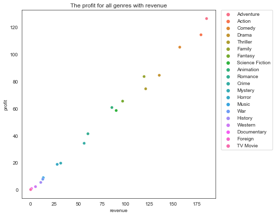

```python
plt.figure(figsize=(7,7))
plt.title('The profit for all genres with revenue')
plt.xlabel('revenue')
plt.ylabel('profit')
sns.scatterplot(x="revenue", y="profit", hue="genres", data=df_rev)
plt.legend(bbox_to_anchor=(1.03, 1), loc=2, borderaxespad=0);
```

> - Adventure is the top in the profit chart with profit morethan 120 billion dollars.
> - Action is the following one in the profit chart.
> - TV movie is the lowest profit in the profit chart bellow the 20 billion dollars.

### 3. Do the movies that get high ratings by the audience depend on their length?

```python
# Calculating the mean for avarge votes
df['vote_average'].mean()
```

```
6.163299392640229
```

```python
# Calculating the mean for movies runtime
df['runtime'].mean()
```

```
108.8311003929975
```

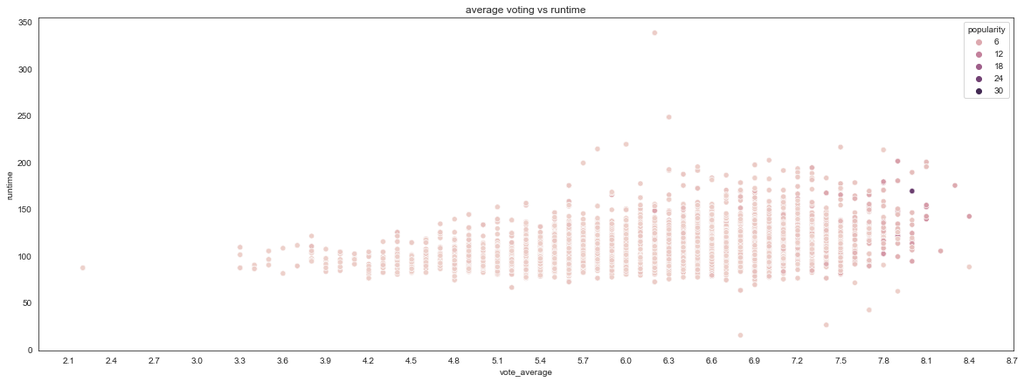

```python
plt.figure(figsize=(20,7))
plt.title('average voting vs runtime')
plt.xticks(np.arange(0,10,0.3))
sns.set_style("whitegrid")
sns.scatterplot(x='vote_average',y='runtime',hue='popularity',data=df);
```

> The plot shows that there are some movies with high average rate and also long runtime as the runtime is more than the average, some of the science fiction,history and adventures movies are long in runtime and also they frequently got appealing by the audience and give them high ratings.

### 4. Movies runtime is the same over the years?

```python
df_runtime = df.copy()

# Dropping the genres and director columns beacause they have many dupliactes rows for the runtime values and we don't
#need them in our analysis
df_runtime.drop(['genres','director'], axis=1, inplace=True)
df_runtime.drop_duplicates(inplace=True)
```

```python
# calculate the mean runtime for each group for the release year
df_runtime = df_runtime.groupby('release_year').mean()['runtime']
df_runtime
```

```
release_year
1960    130.000000
1961    132.500000
1962    141.285714
1963    153.500000
1964    122.428571
1965    167.600000
1966    132.200000
1967    118.384615
1968    130.777778
1969    127.500000
1970    121.454545
1971    112.615385
1972    113.000000
1973    111.916667
```

[output cut: 43 more lines]

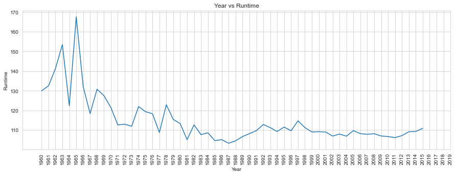

```python
plt.figure(figsize=(15,5))
sns.lineplot(x=df_runtime.index, y=df_runtime.values)
plt.ylabel("Runtime")
plt.xlabel("Year")
plt.xticks(np.arange(df_runtime.index.min(), df_runtime.index.max()+5))
plt.xticks(rotation=90)
plt.title('Year vs Runtime');
```

> As shown from the plot that the runtime is decreasing over the years, and that makes sense as people tends to watch movies with short duration rather than long duration. Movies from 2008 till 2015 durations tend to be in range of 100 minutes which is nearly hour and half.

### 5. Top 20 directors in terms of number of movies released?

```python
# grouping the director column to count the number of movies produced and released for them all over the years.
df_director=df.groupby('director').count()['id'].reset_index(name="count").sort_values(by=['count'],ascending=False,axis=0)
df_director[:20]
```

|  | director | count |
| --- | --- | --- |
| 1614 | Steven Spielberg | 78 |
| 280 | Clint Eastwood | 68 |
| 1397 | Ridley Scott | 66 |
| 1660 | Tim Burton | 52 |
| 1436 | Robert Rodriguez | 51 |
| 1444 | Robert Zemeckis | 49 |
| 1367 | Renny Harlin | 47 |
| 1375 | Richard Donner | 47 |
| 803 | Joel Schumacher | 45 |
| 1613 | Steven Soderbergh | 45 |
| 1771 | Woody Allen | 43 |
| 1710 | Tony Scott | 41 |
| 185 | Brian De Palma | 41 |
| 1129 | Michael Bay | 39 |
| 1466 | Ron Howard | 39 |
| 513 | Francis Ford Coppola | 38 |
| 814 | John Carpenter | 37 |
| 1099 | Martin Scorsese | 35 |
| 434 | Don Bluth | 35 |
| 1739 | Walter Hill | 35 |

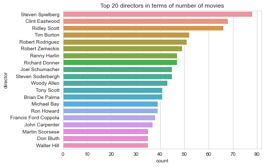

```python
plt.figure(figsize=(7,5))
plt.title('Top 20 directors in terms of number of movies')
plt.xlabel('number of movies')
plt.ylabel('directors')
sns.barplot(x="count", y="director", data=df_director.head(20));
```

### 6. Type of movies which has the longest duration?

```python
# grouping the genre and calculating the mean runtime for each group in desc. order.
df_movie = df.groupby('genres').runtime.mean().sort_values(ascending=False).reset_index(name='count')
df_movie
```

|  | genres | count |
| --- | --- | --- |
| 0 | History | 143.977612 |
| 1 | War | 131.333333 |
| 2 | Western | 126.741379 |
| 3 | Foreign | 120.714286 |
| 4 | Drama | 115.669575 |
| 5 | Mystery | 111.942529 |
| 6 | Action | 111.906034 |
| 7 | Crime | 111.388972 |
| 8 | Adventure | 111.305389 |
| 9 | Romance | 110.480114 |
| 10 | Thriller | 109.482841 |
| 11 | Science Fiction | 108.066308 |
| 12 | Music | 106.836601 |
| 13 | Fantasy | 105.426667 |
| 14 | Comedy | 101.185505 |
| 15 | Horror | 99.912602 |
| 16 | Documentary | 98.687500 |
| 17 | Family | 96.604089 |
| 18 | TV Movie | 89.000000 |
| 19 | Animation | 88.710692 |

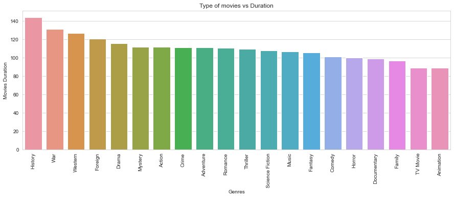

```python
plt.figure(figsize=(15,5))
sns.barplot(x="genres",y='count', data=df_movie)
plt.title('Type of movies vs Duration')
plt.xticks(rotation=90)
plt.xlabel('Genres')
plt.ylabel('Movies Duration');
```

> As shown in the plot historical movies has the longest runtime(duration) it is more than 2 hours. Also the war movies come in second place they are nearly 2 hours. The animation and TV movies are in range of 90 minutes (which is hour and half) and that is suitable time for that type of movies and that are usually their runtime.